# Neural Networks

Neural networks are a biologically inspired model which has had considerable engineering success in applications ranging from time series prediction to vision. Neural networks are a generalization of the perceptron which uses a feature transform that is learned from the data. As such, they are a very powerful and flexible model.

Neural networks are a good candidate model for learning from data because they can efficiently approximate complex target functions and they come with good algorithms for fitting the data.

## The Multi-layer Perceptron (MLP)

The perceptron cannot implement simple classification functions. To illustrate, we use the target related to the boolean XOR function. In this example, $f$ cannot be written as $sign(\mathbf{w}^T \mathbf{x})$. However, $f$ is composed of two linear parts.

[figure not shown]

Indeed we can decompose $f$ into two simple perceptrons, corresponding to the lines in the figure, and then combine the outputs of these two perceptrons in a simple way to get back $f$.

[figure not shown]

The target $f$ equals $+1$ when exactly one of $h_1, h_2$ equals $+1$. We can rewrite $f$ using the simpler OR and AND operations. Using standard Boolean notation

$$ f = h_1 \bar{h_2} + \bar{h_1} h_2 $$

This is a useful insight, because OR and AND can be implemented by the perceptron:

$$ OR(x_1, x_2) = sign(x_1 + x_2 + 1.5)\\ AND(x_1, x_2) = sign(x_1 + x_2 − 1.5) $$

This implies that these more complicated targets are ultimately just combinations of perceptrons. To see how to combine the perceptrons to get $f$, we introduce a graph representation of perceptrons, starting with OR and AND:

[figure not shown]

### The MLP for a Complex Target.

Since $f = h_1 \bar{h_2} + \bar{h_1} h_2$, which is an OR of the two inputs. We first use the OR perceptron, to obtain:

[figure not shown]

The two inputs $h_1 \bar{h_2}$ and $\bar{h_1} h_2$ are ANDs. As such, they can be simulated by the output of two and perceptrons. To deal with negation of the inputs to the AND, we negate the weights multiplying the negated inputs. The resulting graph representation of $f$ is:

[figure not shown]

The blue and red weights are simulating the required two ands. Finally, since $h_1 = sign(\mathbf{w_1}^T \mathbf{x})$ and $h_1 = sign(\mathbf{w_2}^T \mathbf{x})$ are perceptrons, we further expand the $h_1$ and $h_2$ nodes to obtain the graph representation of $f$.

[figure not shown]

Compared with the simple Perceptron, more layers of nodes are used between the input and output to implement $f$ , as compared to the simple perceptron, hence we call it a multilayer layer perceptron (MLP). The additional layers are called *hidden layers*.

If $f$ can be decomposed into perceptrons using an OR of ANDs, then it can be implemented by a 3-layer perceptron. If $f$ is not strictly decomposable into perceptrons, but the decision boundary is smooth, then a 3-layer perceptron can come arbitrarily close to implementing $f$.

[figure not shown]

We have thus found a generalization of the simple perceptron that looks much like the simple perceptron itself, except for the addition of more layers. We gained the ability to model more complex target functions by adding more nodes (hidden units) in the hidden layers. In fact, a suitably large 3-layer MLP can closely approximate just about any target function, and fit any data set, so it is a very powerful learning model. Use it with care. If your MLP is too large you may lose generalization ability.

Once you fix the size of the MLP (number of hidden layers and number of hidden units in each layer), you learn the weights on every link (arrow) by fitting the data.

Let’s consider the simple perceptron,

$$ h(\mathbf{x}) = \theta(\mathbf{w}^T \mathbf{x}) $$

When $\theta(s) = sign(s)$, learning the weights was already a hard combinatorial problem. The combinatorial optimization problem is even harder with the MLP, for the same reason, namely that the $sign(\cdot)$ function is not smooth; a smooth, differentiable approximation to $sign(\cdot)$ will allow us to use analytic methods, rather than purely combinatorial methods, to find the optimal weights. We therefore approximate, or "soften" the $sign(\cdot)$ function by using the $tanh(\cdot)$ function.

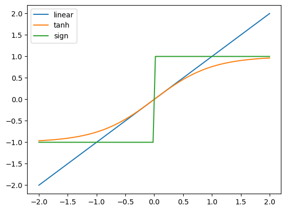

```python
ax.figure
```

## Neural Networks

The neural network is our "softened" MLP. Let’s begin with a graph representation of a feed-forward neural network.

[figure not shown]

### Notation

[figure not shown]

| Name | Symbol | Dimensions |
| --- | --- | --- |
| signals in | $$\mathbf{s}^{(l)}$$ | $$d^{(l)}$$ |
| outputs | $$\mathbf{x}^{(l)}$$ | $$d^{(l)} + 1$$ |
| weights in | $$W^{(l)}$$ | $$(d^{(l-1)} + 1) \times d^{(l)}$$ |
| weights out | $$W^{(l+1)}$$ | $$(d^{(l)} + 1) \times d^{(l+1)}$$ |

### Forward Propagation to compute $h(\mathbf{x})$

1. $$\mathbf{x}^{(0)} \leftarrow \mathbf{x}$$
2. For $l=1, \cdots, L$ do
3. $\quad s^{(l)} \leftarrow (W^{(l)})^T \mathbf{x}^{(l-1)}$
4. $\quad \mathbf{x}^{(l)} \leftarrow \bigl[ \begin{smallmatrix} 1 \\ \theta(\mathbf{s}^{(l)}) \end{smallmatrix} \bigr]$
5. $h(\mathbf{x}) = \mathbf{x}^{(L)}$

[figure not shown]

If we want to compute $E_{in}$, all we need is $h(\mathbf{x}_n)$ and $y_n$ . For the sum of squares,

$$ \begin{align*} E_{in} & = & \frac{1}{N} \sum_{n=1}^N (h(\mathbf{x}_n; \mathbf{w}) - y_n)^2\\ & = & \frac{1}{N} \sum_{n=1}^N (\mathbf{x}_n^{(L)} - y_n)^2 \end{align*} $$

We now discuss how to minimize $E_{in}$ to obtain the learned weights. It will be a direct application of gradient descent, with a special algorithm that computes the gradient efficiently.

### Backpropagation Algorithm

Consider an in-sample error which is the sum of the point-wise errors over the data points (as is the squared in-sample error),

$$ E_{in}(\mathbf{w}) = \frac{1}{N} \sum_{n=1}^N e_n $$

where $e_n = e(h(\mathbf{x}_n ), y_n)$. For the squared error, $e(h, y) = (h − y)^2$. To compute the gradient of $E_{in}$, we need its derivative with respective to each weight matrix:

$$ \frac{\partial E_{in}}{\partial W^{(l)}} = \frac{1}{N} \sum_{n=1}^N \frac{\partial e_n}{\partial W^{(l)}} $$

The basic building block is the partial derivative of the error on a data point $e$, with respect to the $W^{(l)}$.

Backpropagation is based on several applications of the chain rule to write partial derivatives in layer $l$ using partial derivatives in layer $(l + 1)$. To describe the algorithm, we define the sensitivity vector for layer $l$, which is the sensitivity (gradient) of the error $e$ with respect to the input signal $s^{(l)}$.

$$ \boldsymbol{\delta}^{(l)} = \frac{\partial e}{\partial \mathbf{s}^{(l)}} $$

The sensitivity quantifies how $e$ changes with $s^{(l)}$. Using the sensitivity, we can write the partial derivatives with respect to the weights $W^{(l)}$ as

$$ \frac{\partial e}{\partial w_{ij}^{(l)}} = \frac{\partial \mathbf{s}_j^{(l)}}{\partial w_{ij}^{(l)}} \frac{\partial e}{\partial \mathbf{s}_j^{(l)}} = \mathbf{x}_i^{(l-1)} \boldsymbol{\delta}^{(l)}_j $$

Where the last equality follows because $\mathbf{s}_j^{(l)} = \sum_{k=0}^{d^{(l-1)}} w_{kj}^{(l)} \mathbf{x}_k^{(l-1)}$ and by the definition of $\boldsymbol{\delta}^{(l)}_j$.

The outputs $\mathbf{x}^{(l)}$ for every layer $l \geq 0$ can be computed by a forward propagation. It turns out that the sensitivity vectors can be obtained by running a slightly modified version of the neural network backwards, and hence the name backpropagation.

In forward propagation, each layer outputs the vector $\mathbf{x}^{(l)}$ and in backpropagation, each layer outputs (backwards) the vector $\boldsymbol{\delta}^{(l)}$. In forward propagation, we compute $\mathbf{x}^{(l)}$ from $\mathbf{x}^{(l-1)}$ and in backpropagation, we compute $\boldsymbol{\delta}^{(l)}$ from $\boldsymbol{\delta}^{(l+1)}$.

Now we are going to derive the sensivity components. Since $e$ depends on $\mathbf{s}^{(l)}$ only through $\mathbf{x}^{(l)}$, by the chain rule we have

$$ \boldsymbol{\delta}^{(l)}_j = \frac{\partial e}{\partial \mathbf{s}_j^{(l)}} = \frac{\partial e}{\partial \mathbf{x}_j^{(l)}} \frac{\partial \mathbf{x}_j^{(l)}}{\partial \mathbf{s}_j^{(l)}} = \theta'\left(\mathbf{s}_j^{(l)}\right) \frac{\partial e}{\partial \mathbf{x}_j^{(l)}} $$

Because a particular component of $\mathbf{x}^{(l)}$ can affect every component of $\mathbf{s}^{(l+1)}$, we need to sum these dependencies using the chain rule:

$$ \frac{\partial e}{\partial \mathbf{x}_j^{(l)}} = \sum_{k=1}^{d^{(l+1)}} \frac{\partial \mathbf{s}_{k}^{(l+1)}}{\partial \mathbf{x}_j^{(l)}} \frac{\partial e}{\partial \mathbf{s}_{k}^{(l+1)}} = \sum_{k=1}^{d^{(l+1)}} w_{jk}^{(l+1)} \boldsymbol{\delta}_k^{(l+1)} $$

Observe that if we know $\boldsymbol{\delta}^{(l+1)}$, then you can get $\boldsymbol{\delta}_{(l)}$. We use $\boldsymbol{\delta}_{(L)}$ to seed the backward process, and we can get that explicitly because $e=\left( \mathbf{x}^{(L)} − y \right)^2 = \left( \theta(\mathbf{s}^{(L)}) − y \right)^2$. Therefore

$$ \boldsymbol{\delta}^{(L)} = \frac{\partial e}{\partial \mathbf{s}^{(L)}} = 2 \left( \mathbf{x}^{(L)} − y \right) \frac{\partial \mathbf{x}^{(L)}}{\partial \mathbf{s}^{(L)}} = 2 \left( \mathbf{x}^{(L)} − y \right) \theta'\left( \mathbf{s}^{(L)} \right) $$

### Back Propagation to Compute Sensitivities $\boldsymbol{\delta}^{(l)}$

**Input**: A data point $(\mathbf{x}, y)$

1. Run forward propagation on $\mathbf{x}$ tocompute and save $$ \mathbf{s}^{(l)} \quad \text{for } l=1, \cdots, L \\ \mathbf{x}^{(l)} \quad \text{for } l=1, \cdots, L $$
2. $\boldsymbol{\delta}^{(L)} \leftarrow 2 \left(\mathbf{x}^{(L)} - y \right) \theta'\left( \boldsymbol{s}^{(L)} \right)$
3. for $l=L-1$ to $1$ do:
4. $\quad$ Compute the sensivity $\boldsymbol{\delta}^{(l)}$ from $\boldsymbol{\delta}^{(l+1)}$:

$$ \boldsymbol{\delta}^{(l)} \leftarrow \theta'\left( \boldsymbol{s}^{(l)} \right) \otimes \left[ W^{(l+1)} \boldsymbol{\delta}^{(l+1)} \right]_{1}^{d^{(l)}} $$

### Algorithm to Compute $E_{in}(\mathbf{w})$ and $g=\nabla E_{in}(\mathbf{w})$

**Input**: $\mathbf{w} = \{ W^{(1)}, \cdots, W^{(L)}\}; \mathcal{D}=\{(\mathbf{x}_1, y_1), \cdots, (\mathbf{x}_N, y_N)\}$

**Output**: Error $E_{in}(\mathbf{w})$ and gradient $\mathbf{g} = \{ G^{(1)}, \cdots, G^{(L)}\}$

1. Initialize $E_{in}=0$ and $G^{(l)}=0$ for $l=1,\cdots,L$
2. For each data point $(\mathbf{x}_n, y_n), n=1,\cdots,N$ do
3. $\quad$ Compute $\mathbf{x}^{(l)}$ for $l=0,\cdots,L$ [Forward propagation]
4. $\quad$ Compute $\boldsymbol{\delta}^{(l)}$ for $l=L,\cdots,1$ [Backpropagation]
5. $\quad E_{in} \leftarrow E_{in} + \frac{1}{N} \left( \boldsymbol{x}^{(L)} - y_n \right)^2$
6. $\quad$ for $l=1,\cdots,L$ do:
7. $\quad \quad G^{(l)}(\mathbf{x}_n) = \left[ \mathbf{x}^{(l-1)} \left( \boldsymbol{\delta}^{(l)} \right)^T \right]$
8. $\quad \quad G^{(l)} \leftarrow G^{(l)} + \frac{1}{N} G^{(l)}(\mathbf{x}_n)$

## Regularization and Validation

The multi-layer neural network is powerful, and, coupled with gradient descent (a good algorithm to minimize $E_{in}$), we have a recipe for overfitting. We discuss some practical techniques to help.

### Weight Based Complexity Penalties

As with linear models, one can regularize the learning using a complexity penalty by minimizing an augmented error (penalized in-sample error). The squared weight decay regularizer is popular, having augmented error:

$$ E_{aug}(\mathbf{w}) = E_{in}(\mathbf{w}) + \frac{\lambda}{N} \sum_{l,i,j} (w^{(l)}_{i,j})^2 $$

The regularization parameter $\lambda$ is selected via validation. To apply gradient descent, we need $\nabla E_{aug}(\mathbf{w})$. The penalty term adds to the gradient a term proportional to weights

$$ \frac{\partial E_{aug}(\mathbf{w})}{\partial W^{(l)}} = \frac{\partial E_{in}(\mathbf{w})}{\partial W^{(l)}} + \frac{2 \lambda}{N} W^{(l)} $$

Another similar regularizer is *weight elimination*, having augmented error:

$$ E_{aug}(\mathbf{w}) = E_{in}(\mathbf{w}) + \frac{\lambda}{N} \sum_{l,i,j} \frac{(w^{(l)}_{i,j})^2}{1 + (w^{(l)}_{i,j})^2} $$

For a small weight, the penalty term is much like weight decay, and will decay that weight to zero. For a large weight, the penalty term is approximately a constant, and contributes little to the gradient.

### Early Stopping

An iterative method such as gradient descent does not explore your full hypothesis set all at once. With more iterations, more of your hypothesis set is explored. This means that by using fewer iterations, you explore a smaller hypothesis set and should get better generalization.

Consider fixed-step gradient descent with step size $\eta$. At the first step, we start at weights $\mathbf{w}_0$, and take a step of size $\eta$ to $\mathbf{w}_1 = \mathbf{w}_0 - \eta \mathbf{g}_0 / ||\mathbf{g}_0||$. Because we have taken a step in the direction of the negative gradient, we have "looked at" all the hypotheses in the shaded region.

[figure not shown]

This is because a step in the negative gradient leads to the sharpest decrease in $E_{in}(\mathbf{w})$, and so $\mathbf{w}_1$ minimizes $E_{in}(\mathbf{w})$ among all weights with $|| \mathbf{w} - \mathbf{w}_0|| \leq \eta$. We indirectly searched the entire hypothesis set

$$ \mathcal{H}_1 = \{\mathbf{w} : || \mathbf{w} - \mathbf{w}_0|| \leq \eta\}, $$

and picked the hypothesis $\mathbf{w}_1 \in \mathcal{H}_1$ with minimum in-sample error.

$$ \mathcal{H}_2 = \mathcal{H}_1 \cup \{\mathbf{w} : || \mathbf{w} - \mathbf{w}_1|| \leq \eta\}, $$

[figure not shown]

We can continue this argument as gradient descent proceeds, and define a nested sequence of hypothesis sets

$$ \mathcal{H}_1 \subset \mathcal{H}_2 \subset \mathcal{H}_3 \subset \mathcal{H}_4 \subset \cdots $$

As $t$ increases, $E_{in}(\mathbf{w}_t)$ is decreasing, but it doesn't mean that necessarily $E_{out}(\mathbf{w}_t)$ also does.

[figure not shown]

The figure suggests it may be better to stop early at some $t^∗$, well before reaching a minimum of $E_{in}$. Indeed, this picture is observed in practice.